# 1. 問題設定

このレポートでは、二次元平面内で点電荷により有限導体板に誘導される電荷の量を数値計算する。具体的には以下のように、二次元平面上に長方形型の導体板があり、2辺の長さは$a_x$と$a_y$である。さらに、その$h$だけ上の場所に電荷$q$の点電荷があるような状況を考える。なお、点電荷は長方形の辺$a_x$の中点の真上にあるとする。なお、ポテンシャルの原点は無限遠にあり、導体は接地していないことを想定している。

[figure not shown]

# 2. 理論的な検討

今回の問題は以下のように解くことができるだろう。まずは系のポテンシャルを$\Phi(\mathbf{r})$とするとポアソン方程式は次のように表せる。

$$\nabla^2 \Phi(\mathbf{r}) = - q \delta(\mathbf{r} - \mathbf{r}_0) $$

なお、今回は$\varepsilon_0 = 1$という単位系で議論を進めることにする。また$\mathbf{r_0}$は点電荷の位置ベクトルである。ここで、今回の場合この$\Phi$に課せられる境界条件が特殊である。というのも無限遠で$0$というのに加えて導体の表面及び内部で同じ値にならなければならないからだ。

一般にこのような一種の境界値問題は、鏡像法と言われる仮想的な電荷を適当な場所に置くことで系の様子を再現し解析的に計算を行うことができることがある。しかし、この方法では(私の調べた範囲では)今回の問題を解くことができない。つまり、解析的な解を得ることは難しい。そのため数値計算を行う必要がある。

電場$\mathbf{E}$はポテンシャル$\Phi$に対して、$\mathbf{E} = - \nabla \Phi$ として与えられる。また導体表面に現れる電荷の面密度$\sigma$は$\sigma (\mathbf{r}_{surface}) = \mathbf{E} \cdot \mathbf{n}$と表せる。

# 3.数値計算のためのセットアップとコード

数値計算を行う上で、以下のように計算領域を設定した。最も注意すべきなのは、導体を全て一つのセルとして扱っている点である。これは導体内のポテンシャルが一定であるということを表現している。

[figure not shown]

ここで、導体や点電荷は計算領域の$i$軸の中点、また、導体の上辺が$j$軸の半分のところから始まるものとするので、$n_x$、$n_y$、$n_{ax}$は奇数であることを前提とする。

計算では、二次元に広がる$\Phi(\mathbf{r})$を離散化し、さらに一次元のベクトルとして扱う。その際に、物理的な場所とこの一次元ベクトルでの場所(インデックス)の対応関係は以下のように設定した。基本的には、左上から順に横向きに対応させていくが、導体を一つのセルとして扱っている分、注意が必要である。具体的にはインデックスの振り方は一度導体を飛ばして次のセルに次のインデックスを対応させる。そして、ベクトルの一番最後は導体のセルに対応させている。

[figure not shown]

この規則に則ると、導体外の点はその物理的な座標$(i,j)$に対して、一次元配列のインデックス$\mathrm{index}(i, j)$は以下のように表せる。

$$\mathrm{index}(i, j) = i + j \times n_x - \mathrm{min} \left ( \mathrm{max} \left ( 0, j - \frac{n_y - 1}{2} + \mathrm{step} \left ( i - \frac{n_x - n_ax}{2}\right )\right ), n_{ay} \right ) \times n_{ax}$$

ただし、$\mathrm{step}(x)$は$x$が$0$以上なら、$1$を返し、それ以外は$0$を返す関数である。また、計算に使う$\Phi$の一次元ベクトルの長さは$n_x n_y - n_{ax} n_{ay} + 1$と表せる。もちろん最後の$+1$は導体のセル分の一個である。

さて、今回の数値計算において、最も困難だったのはラプラシアンの設定方法である。これはこの計算に使う一次元ベクトルのインデックスと物理的な位置がかなり複雑であるからである。例えば、導体の隣にあるような点では上下左右で導体のポテンシャルを参照しなければならないが、この場合だけ特別にベクトルの一番最後を参照しなければならない。つまり、点ごとにラプラシアンを作用させた時の参照するべきインデックスが異なっている。

メモリの節約を優先する場合はもちろん疎行列でのラプラシアンの設定が良いのだが、それをプログラム上で実装するのは難しい。そこで、今回は線形演算として設計した。そして、各点に対して隣り合った点のインデックスを格納した配列(リスト)を上下左右の4個分作成した。それぞれのリストの長さは$n_x n_y - n_{ax} n_{ay} + 1$である。さらに、最後に一次元配列と物理的な二次元配列を対応させるために$n_x \times n_y$の行列も作成したので、かなりメモリの効率が悪い。ここは改良の余地があるだろう。

なお、今回のコードの作成においてはChatGPTを用いた箇所がある。特に、計算結果の描画においてはよく用いた。

ここまでで、実装の方法の説明を終わり、以下に実際のコードを示す。

```python
import numpy as np
import matplotlib.pyplot as plt
import scipy.sparse as sp

class simulator_2d():
    def __init__(self, nx, ny, nax, nay, q, nh, diff):
        """
        nay=0とすれば、導体なしの場合にできます。
        """
        if nx*ny*nax % 2 == 0:
            raise ValueError("nx*ny*nax must be odd.")

        self.nx = nx
        self.ny = ny
        self.nax = nax
        self.nay = nay
        self.q = q
        self.nh = nh
        self.diff = diff
        self.size = nx * ny - nax * nay + 1

        self.rho = np.zeros(self.size)
        self.rho[self.index((self.nx-1)//2, (self.ny-1)//2 - self.nh)] = self.q / (self.diff ** 2) # 点電荷ではなく、セル内に一様に分布していると考える

        self.index_list_right = np.zeros_like(self.rho, dtype=object)
        self.index_list_left = np.zeros_like(self.rho, dtype=object)
        self.index_list_up = np.zeros_like(self.rho, dtype=object)
        self.index_list_down = np.zeros_like(self.rho, dtype=object)
        self.map = np.zeros(nx*ny, dtype=int)

        for j in range(self.ny):
            for i in range(self.nx):
                idx = self.index(i, j)
                self.map[i + j*self.nx] = idx
                if i == 0:
                    self.index_list_left[idx] = None
                else:
                    self.index_list_left[idx] = self.index(i-1, j)

                if i == self.nx - 1:
                    self.index_list_right[idx] = None
                else:
                    self.index_list_right[idx] = self.index(i+1, j)

                if j == 0:
                    self.index_list_up[idx] = None
                else:
                    self.index_list_up[idx] = self.index(i, j-1)

                if j == self.ny - 1:
                    self.index_list_down[idx] = None
                else:
                    self.index_list_down[idx] = self.index(i, j+1)

        # 上下左右のインデックスのリスト
        self.mask_right = (self.index_list_right == None)
        self.index_list_right = np.where(self.mask_right, 0, self.index_list_right).astype(int)
        self.mask_left = (self.index_list_left == None)
        self.index_list_left = np.where(self.mask_left, 0, self.index_list_left).astype(int)
        self.mask_up = (self.index_list_up == None)
        self.index_list_up = np.where(self.mask_up, 0, self.index_list_up).astype(int)
        self.mask_down = (self.index_list_down == None)
        self.index_list_down = np.where(self.mask_down, 0, self.index_list_down).astype(int)

    def step(self, x):
        return 0 if x < 0 else 1

    def index(self, i, j):
        if abs(i - (self.nx-1)//2) <= (self.nax-1)//2 and 0 <= j-(self.ny-1)//2 < self.nay:
            return -1
        else:
            return i + j * self.nx - min((max(0, j - (self.ny-1)//2 + self.step(i - (self.nx-self.nax)//2))), self.nay) * self.nax

    def re_index(self, array):
        return array[self.map].reshape(self.ny, self.nx)

    def test(self):
        for j in range(self.ny):
            print(self.map[j*self.nx:(j+1)*self.nx])

    def laplacian(self, phi):
        phi_right = np.where(self.mask_right, 0, phi[self.index_list_right])
        phi_left = np.where(self.mask_left, 0, phi[self.index_list_left])
        phi_up = np.where(self.mask_up, 0, phi[self.index_list_up])
        phi_down = np.where(self.mask_down, 0, phi[self.index_list_down])
        return (phi_right + phi_left + phi_up + phi_down - 4 * phi) / (self.diff ** 2)

    def poisson_solver(self, vector=False):
        A = sp.linalg.LinearOperator((self.size, self.size), matvec=lambda phi: -self.laplacian(phi))
        result = sp.linalg.bicgstab(A, self.rho)
        if vector:
            return result[0], self.re_index(result[0])
        else:
            return self.re_index(result[0])

    def plot(self, phi, E=False, step=25):
        """与えられた二次元配列をメッシュグリッド上に描画する関数"""

        s = "nx:" + str(self.nx) + " ny:" + str(self.ny) + " nax:" + str(self.nax) + " nay:" + str(self.nay) + " q:" + str(self.q) + " nh:" + str(self.nh) + " diff:" + str(self.diff)
        phi = np.flipud(phi) # 上下逆転で右手系に
        x = np.arange(self.nx + 1) * self.diff
        y = np.arange(self.ny + 1) * self.diff
        X, Y = np.meshgrid(x, y, indexing='xy') # xyにしないと電場のプロットがうまくいかない

        plt.pcolormesh(X, Y, phi, shading='auto')
        plt.colorbar()

        if self.nay > 0:
            i0 = (self.nx - self.nax) // 2
            j0 = (self.ny-1) // 2 - self.nay + 1
            x0 = i0 * self.diff
            y0 = j0 * self.diff
            rect = plt.Rectangle((x0, y0), self.nax*self.diff, self.nay*self.diff, linewidth=1, edgecolor='r', facecolor='none')
            plt.gca().add_patch(rect)

        if E:
            Ey, Ex = np.gradient(-phi, self.diff, self.diff)
            skip = (slice(None, None, step), slice(None, None, step))
            plt.quiver(X[skip], Y[skip], Ex[skip], Ey[skip], color='w')

        plt.xlabel('x')
        plt.ylabel('y')
        plt.gca().set_aspect("equal", adjustable="box")
        plt.title(s)
        plt.show()

    def Ey_plot(self, phi):
        """縦方向の電場の変化を見る関数"""
        phi = np.flipud(phi)
        Ey, _ = np.gradient(-phi, self.diff, self.diff)
        i0 = (self.ny-1) // 2

        plt.plot(range(self.ny)[::-1], Ey[:, (self.nx-1)//2], label='Ey along center line')
        plt.plot((self.ny-1)//2 - self.nh, Ey[(self.ny-1)//2 + self.nh, (self.nx-1)//2], 'ro', label='charge position', alpha=0.5)
        plt.plot(i0, Ey[i0, (self.nx-1)//2], 'go', label='metal surface start', alpha=0.5)
        plt.xlabel('j')
        plt.ylabel('Ey')
        plt.legend()
        plt.tight_layout()
        plt.show()


    def induced_charge(self, phi, plot = True):
        """誘導電荷/点電荷　を求める関数"""
        phi = np.flipud(phi)
        Ey, _ = np.gradient(-phi, self.diff, self.diff)
        i0 = (self.nx - self.nax) // 2
        metal_surface = Ey[(self.ny-1)//2, i0 : i0 + self.nax]
        r = sum(metal_surface) * (self.diff) / self.q
        print("induced charge / q:", r)

        if plot:
            plt.plot(range(i0, i0+self.nax), metal_surface)
            plt.xlabel('i')
            plt.ylabel('Ey')
            plt.tight_layout()
            plt.show()

        return r
```

```
ポアソン方程式が解けるのかの確認(実際にラプラシアンを作用させて電荷が同じになるか？)
元の電荷: 10.0 計算の結果の電荷: 9.999999999999968

ポテンシャル及び電場の分布
```

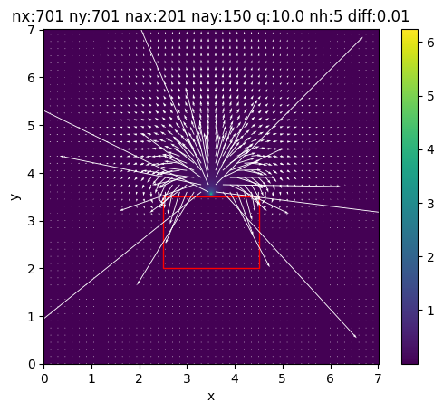

```
j方向の電場変化
```

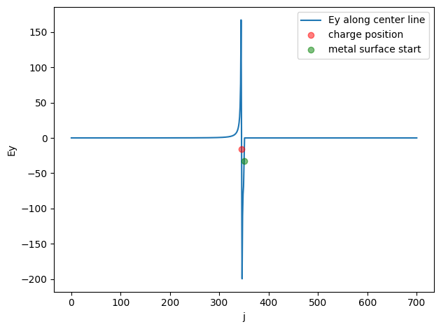

```
誘導電荷/元の電荷の評価
induced charge / q: -0.48467185948555763
```

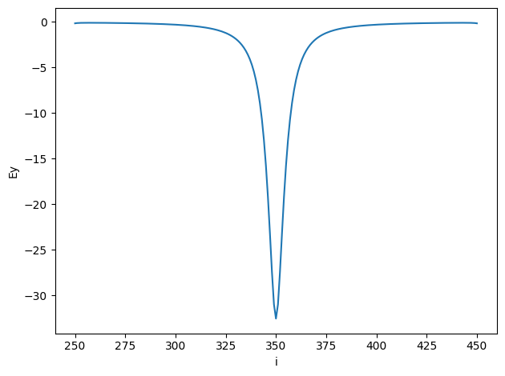

```
np.float64(-0.48467185948555763)
```

```python
simulator = simulator_2d(nx=701, ny=701, nax=201, nay=150, q=10.0, nh=5, diff=0.01)
phi_vec, phi = simulator.poisson_solver(vector=True)
print("ポアソン方程式が解けるのかの確認(実際にラプラシアンを作用させて電荷が同じになるか？)")
print("元の電荷:", 10.0, "計算の結果の電荷:", -simulator.laplacian(phi_vec)[simulator.index((simulator.nx-1)//2, (simulator.ny-1)//2 - simulator.nh)]*(0.01**2))
print("")
print("ポテンシャル及び電場の分布")
simulator.plot(phi, E=True, step=15)
print("j方向の電場変化")
simulator.Ey_plot(phi)
print("誘導電荷/元の電荷の評価")
simulator.induced_charge(phi, plot=True)
```

```
ポアソン方程式が解けるのかの確認(実際にラプラシアンを作用させて電荷が同じになるか？)
元の電荷: 10.0 計算の結果の電荷: 9.999999999999318

ポテンシャル及び電場の分布
```

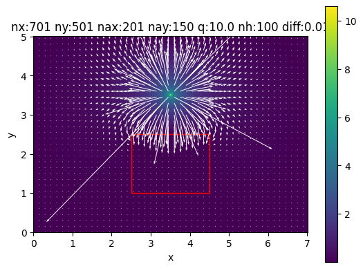

```
j方向の電場変化
```

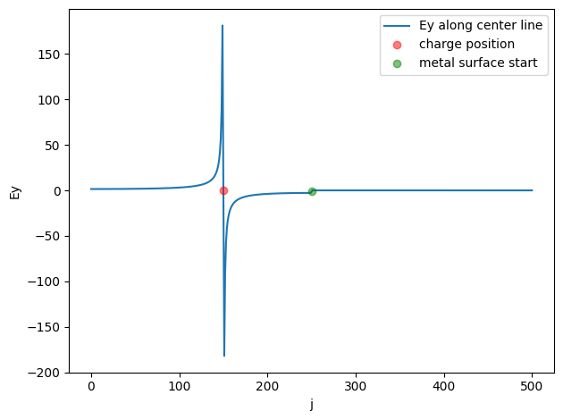

```
誘導電荷/元の電荷の評価
induced charge / q: -0.22289390581970275
```

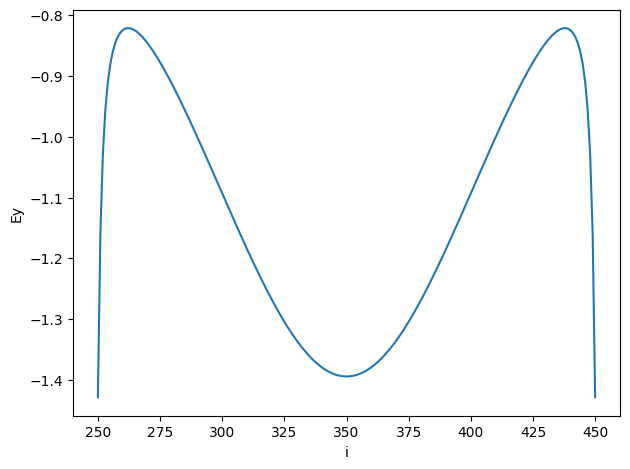

```
np.float64(-0.22289390581970275)
```

```python
simulator2 = simulator_2d(nx=701, ny=501, nax=201, nay=150, q=10.0, nh=100, diff=0.01)
phi_vec2, phi2 = simulator2.poisson_solver(vector=True)
print("ポアソン方程式が解けるのかの確認(実際にラプラシアンを作用させて電荷が同じになるか？)")
print("元の電荷:", simulator2.q, "計算の結果の電荷:", -simulator2.laplacian(phi_vec2)[simulator2.index((simulator2.nx-1)//2, (simulator2.ny-1)//2 - simulator2.nh)]*(simulator2.diff**2))
print("")
print("ポテンシャル及び電場の分布")
simulator2.plot(phi2, E=True, step=15)
print("j方向の電場変化")
simulator2.Ey_plot(phi2)
print("誘導電荷/元の電荷の評価")
simulator2.induced_charge(phi2, plot=True)
```

```
ポアソン方程式が解けるのかの確認(実際にラプラシアンを作用させて電荷が同じになるか？)
元の電荷: 10.0 計算の結果の電荷: 10.000000000009248

ポテンシャル及び電場の分布
```

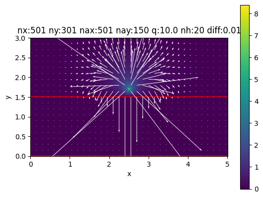

```
j方向の電場変化
```

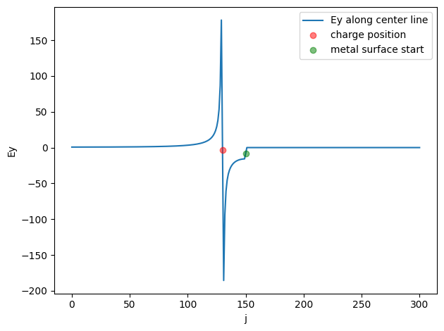

```
誘導電荷/元の電荷の評価
induced charge / q: -0.4320202937588583
```

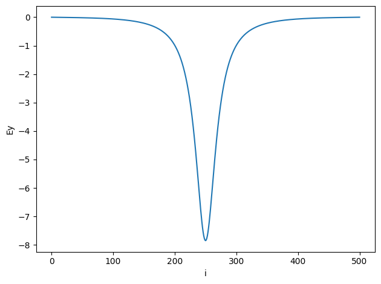

```
np.float64(-0.4320202937588583)
```

```python
simulator3 = simulator_2d(nx=501, ny=301, nax=501, nay=150, q=10.0, nh=20, diff=0.01)
phi_vec3, phi3 = simulator3.poisson_solver(vector=True)
print("ポアソン方程式が解けるのかの確認(実際にラプラシアンを作用させて電荷が同じになるか？)")
print("元の電荷:", 10.0, "計算の結果の電荷:", -simulator3.laplacian(phi_vec3)[simulator3.index((simulator3.nx-1)//2, (simulator3.ny-1)//2 - simulator3.nh)]*(simulator3.diff**2))
print("")
print("ポテンシャル及び電場の分布")
simulator3.plot(phi3, E=True, step=15)
print("j方向の電場変化")
simulator3.Ey_plot(phi3)
print("誘導電荷/元の電荷の評価")
simulator3.induced_charge(phi3, plot=True)
```

# 4. 考察

ここでは計算結果の評価と考察を行う。

まずは、ポアソン方程式の数値解を考える。これは計算結果をラプラシアンに作用させた時に、元の電荷とほとんど同じ値を返すので、適当な結果と考えられる。また電場の様子から、導体の存在が与える影響を見ることができるため、数値計算は適切な値を計算していると言えるだろう。

縦方向の電場変化に関しても、電荷の位置を境に正負(向き)が変化していることや、その周りでの値が極端に大きいことは定性的に考えても自然である。さらに、導体に関して点電荷と反対な領域では常に電場が0であるように見えるがこれは中央線の電場変化を見ているため対称性の観点からこのような結果が得られることは説明できるだろう。

次に誘導電荷の評価を行う。誘導電荷は無限に導体が広がっている場合には誘導電荷全体では元の電荷と大きさが同じで電荷が逆になることが知られている。今回、直感的には誘導される電荷は反対のままであるが、大きさが小さくなる分、誘導電荷の総量の大きさも小さくなると予想できる。その点ではこの予想と矛盾しない結果が得られた。しかしながら、逆に導体の横幅$n_{ax}$を計算領域いっぱい、つまり$n_x$と同じにした場合、これは先ほどの導体が無限に広がっている場合に相当していると考えられるので、先ほどの議論から表示される値(誘導電荷/元の電荷)は$-1$になると期待できる。しかし、上の結果からもわかるようにこのような場合であっても結果は$-0.4$程度になってしまう。

この理由に関しては、大きく三つの可能性が考えられる。一つ目は単純に領域いっぱいの導体であっても「無限に広がっている導体」を表現できていない可能性である。つまり、計算領域外の部分にも誘導されている電荷を考えると合わせて$-1$になる可能性である。しかし、境界付近でのポテンシャルがほとんど$0$で電場がほとんどないと考えられる以上、少し理由としては考えにくい。もう一つは誘導電荷の算出方法自体の問題の可能性である。というのも、理論的な検討で述べた誘導電荷の算出方法は3次元空間にある二次元平面に誘導される誘導電荷を想定している。しかし、今回は二次元空間の一次元平面に誘導される電荷のため、次元に不整合が生じている。そこを今回は奥行方向に単位長さだけ広がっていると考え、長さ$1$を暗黙のうちにかけている。この議論に不適切な点が生じている可能性は大いにあるだろう。最後に計算結果自体の問題も考えられる。先ほどの議論ではポテンシャルの計算結果はラプラシアンに作用させることで評価できたが、電場の評価は定性的な議論でしか正当性を評価できていない。その分、電場の計算結果が不適切な可能性も否定できない。

さらに、これは考えにくいが計算領域の設定にも問題があるかもしれない。というのも、実際の金属では厳密に内部でポテンシャルが一定になっているわけではなく表面付近の薄い領域で変化する。今回の計算ではこれを考慮していないので、この影響も考えられるだろう。

最後に誘導電荷の分布についてだが、計算結果を見ると点電荷が離れた場合少し特徴的な分布をしていることがわかる。これについての理論的な考察ができれば、計算結果自体の正当性の評価につながると期待できたが、そこまでの結論は得られなかった。